# Maximum Likelihood Method

Dr. Josh Jacobson

23 February 2026

*These lecture notes were originally developed by Dr. Kris Pruitt.*

The purpose of this lesson is to derive and explain the parameter estimates for a simple logistic regression model using the maximum likelihood criterion. We will leverage methods from calculus and linear algebra for the derivation.

# Maximum Likelihood Criterion

After visually confirming in a box plot or scatter plot that a continuous predictor $x$ is associated with a binary response $y$, we wish to estimate the following logistic function.

$$p(x)=P(y=1|x)=\frac{1}{1+e^{-(\beta_0+\beta_1 x)}}$$

This function suggests an underlying logistic (sigmoid) relationship between the predictor $x$ and the probability that that binary response $y$ is equal to 1. The two unknown parameters $\beta_0$ and $\beta_1$ are what we need to estimate in order to find the best-fit logistic curve. By “best” we mean the curve that maximizes the likelihood of the observed data. This is sometimes referred to as the **likelihood function (L)**. Given a data set $(x_i,y_i)$ for $i=1...n$ we seek estimated values $\hat{\beta}_0$ and $\hat{\beta}_1$ that produce the globally maximum value for L (shown below). Hence the name “maximum likelihood”.

$$\text{L}=\prod_{i=1}^n [\hat{p}_i^{y_i} \cdot (1-\hat{p}_i)^{1-y_i}]$$

When $y_i=1$ we want $\hat{p}_i$ to be as close to 1 as possible. When $y_i=0$ we want $1-\hat{p}_i$ to be as close to 1 as possible. Consequently, we want the product of all the $\hat{p}_i$ and $1-\hat{p}_i$ terms to be as large as possible. This product represents the likelihood of the observed data, assuming observations are independent. What probability distribution does this product remind you of?

For mathematical simplicity, we often maximize the natural logarithm of the likelihood instead. Since the logarithm is a monotonically increasing function, this transformation provides the same optimal solution.

$$\text{log(L)}=\sum_{i=1}^n [y_i
\log(\hat{p}_i)+(1-y_i)\log(1-\hat{p}_i)]$$

In general, the optimal values for $\hat{\beta}_0$ and $\hat{\beta}_1$ cannot be determined explicitly with a closed-form solution. Instead, iterative methods such as *Newton’s Method* are employed until they converge on optimal values. Let’s briefly outline what that algorithm would entail. First, for simplicity, we’ll label $\log(L)$ as $l(\hat{\beta})$ to make clear that the log-likelihood is a function of our estimated $\beta$ parameters. Then, we know the critical values for the parameters must satisfy the following function.

$$l'(\hat{\beta})=0$$

The notation $l'(\hat{\beta})$ represents the vector of partial derivatives (i.e., gradient) with respect to each $\beta$ parameter. The log-likelihood function $l(\hat{\beta})$ is strictly concave. Thus, to find the $\beta$ estimates that maximize $l(\hat{\beta})$, we need only find the roots of the gradient. Newton’s Method is designed for this purpose. At each iteration $(0,1,...,t,t+1,...)$ of the algorithm we find a new vector of parameter estimates $\hat{\beta}$ using the following equation.

$$\hat{\beta}_{t+1}=\hat{\beta}_t-l''(\hat{\beta}_t)^{-1}l'(\hat{\beta}_t)$$

In this case, $l''(\hat{\beta})$ represents the Hessian matrix of second-order partial derivatives, which must be inverted. Though the mathematical notation may seem daunting, the intuition is simple. At each iteration of the algorithm we obtain better estimates for the $\beta$ parameters, which increase the log-likelihood function. Eventually, the log-likelihood stops increasing and we arrive at the maximum. To further emphasize the iterative nature of the maximum likelihood problem, let’s try solving a small problem by hand.

# Numerical Example

We will now use a very small numerical example to demonstrate the log-likelihood function.

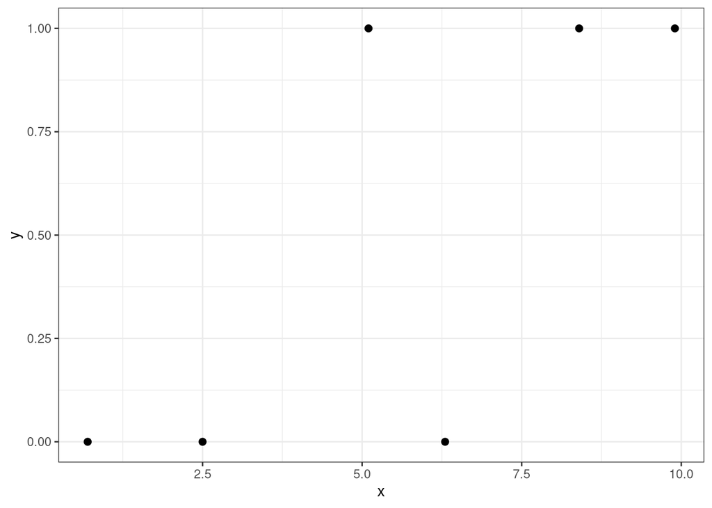

```r
# create data set
my_data <- data.frame(
  x = c(0.7, 2.5, 5.1, 6.3, 8.4, 9.9),
  y = c(0, 0, 1, 0, 1, 1)
)

# plot data
ggplot(data = my_data) +
  geom_point(aes(x, y), size = 2) +
  theme_bw()
```

Let’s start with an initial guess for $\hat{\beta}_0$ and $\hat{\beta}_1$ and compute the log-likelihood.

```r
# pick parameter values
beta0 <- -6
beta1 <- 1.5

# estimate probabilities
my_data2 <- my_data %>%
  mutate(prob = 1 / (1 + exp(-beta0 - beta1 * x)))

# compute log-likelihood
my_data2 %>%
  summarize(sum(y * log(prob) + (1 - y) * log(1 - prob)))
```

| sum(y * log(prob) + (1 - y) * log(1 - prob)) |
| --- |
| -3.765694 |

Now let’s graph the logistic curve associated with these parameter values.

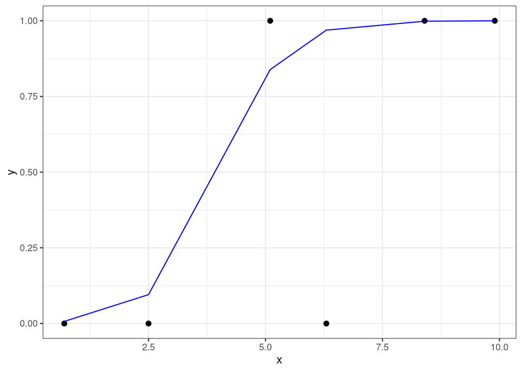

```r
# plot data and fit curve
ggplot(data = my_data2) +
  geom_point(aes(x, y), size = 2) +
  geom_line(aes(x, prob), color = "blue") +
  theme_bw()
```

## Activity

> Can you make adjustments to the parameter values that result in a greater log-likelihood and thus a better fit?

> Try changing just one parameter at a time to assess the impact on both the log-likelihood value and the fitted curve.

After trying your own values, you’ve likely seen that it is very difficult to manually choose new parameter estimates that consistently increase the log-likelihood without a structured algorithm. In practice, we determine the optimal values using the `glm()` function. In the help menu for the `glm()` function, you will find reference to a method called **iteratively reweighted least squares (IRLS)**. This is the algorithm `R` uses to solve the maximum likelihood problem for logistic regression. But IRLS is essentially the same as Newton’s Method, with only minor adjustments to the Hessian matrix.

```r
# fit model
model <- glm(y ~ x, data = my_data, family = "binomial")

# summarize results
summary(model)
```

```
##
## Call:
## glm(formula = y ~ x, family = "binomial", data = my_data)
##
## Coefficients:
##             Estimate Std. Error z value Pr(>|z|)
## (Intercept)  -4.4773     3.7986  -1.179    0.239
## x             0.7977     0.6253   1.276    0.202
##
## (Dispersion parameter for binomial family taken to be 1)
##
##     Null deviance: 8.3178  on 5  degrees of freedom
## Residual deviance: 4.3152  on 4  degrees of freedom
## AIC: 8.3152
##
## Number of Fisher Scoring iterations: 5
```

How close were your parameter estimates to those found by the algorithm? Notice at the bottom of the output a reference to “Fisher Scoring iterations” and a value of 5. This means the IRLS method required 5 iterations to reach the optimal values for the $\beta$ parameters. We can view the best-fit curve associated with these values below.

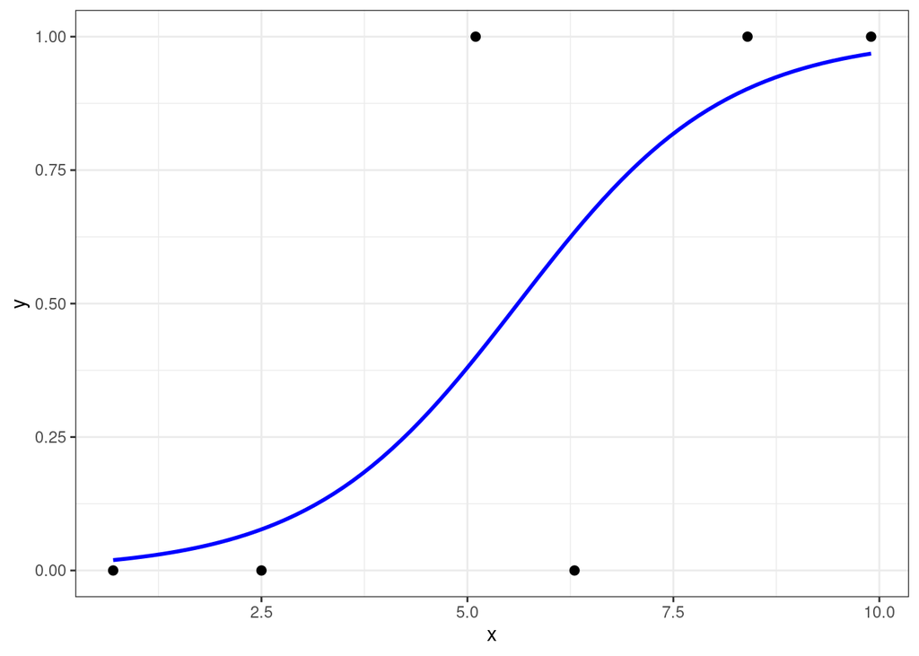

```r
# plot data and best curve
ggplot(data = my_data, aes(x, y)) +
  geom_point(size = 2) +
  geom_smooth(
    formula = y ~ x, method = "glm",
    method.args = list(family = "binomial"), se = FALSE, color = "blue"
  ) +
  theme_bw()
```